# Hayman Fire Recovery

Meggi Varnai

February 06, 2022

```r
####-----Reading in Data and Stacking it ----- ####
#Reading in files
files <- list.files('data',full.names=T)
#Read in individual data files
ndmi <- read_csv(files[1]) %>%
  rename(burned=2,unburned=3) %>%
  mutate(data='ndmi')
ndsi <- read_csv(files[2]) %>%
  rename(burned=2,unburned=3) %>%
  mutate(data='ndsi')
ndvi <- read_csv(files[3])%>%
  rename(burned=2,unburned=3) %>%
  mutate(data='ndvi')
# Stack as a tidy dataset
full_long <- rbind(ndvi,ndmi,ndsi) %>%
  gather(key='site',value='value',-DateTime,-data) %>%
  filter(!is.na(value))
```

## Question 1)

What is the correlation between NDVI and NDMI? - here I want you to convert the full_long dataset in to a wide dataset using the function “spread” and then make a plot that shows the correlation as a function of if the site was burned or not (x axis should be ndmi) You should exclude winter months and focus on summer months

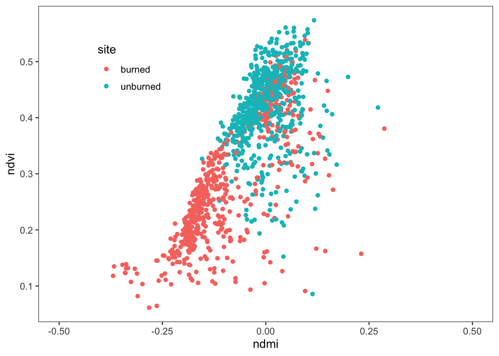

```r
full_wide <- spread(full_long,key='data',value='value') %>%
  filter_if(is.numeric,all_vars(!is.na(.))) %>%
  mutate(month=month(DateTime),
         year=year(DateTime))

#create variable for summer months
var.summer_months<- c(5,6,7,8)

summer<-full_wide %>%
  filter(month %in% var.summer_months)

ggplot(summer,aes(x=ndmi,y=ndvi,color=site))+
  geom_point()+
  xlim(-0.5,0.5)+
  theme_few()+
  theme(legend.position=c(0.2,0.8))
```

```r
#correlation
cor(summer$ndmi,summer$ndvi)
```

```
## [1] 0.6877053
```

A: Based off the plot, there is a positive correlation between ndmi and ndvi. I ran a correlation test as well and found that the correlation for summer months between ndmi and ndvi is 0.68.

## Question 2

2. What is the correlation between average NDSI (normalized snow index) for January - April and average NDVI for June-August? In other words, does the previous year’s snow cover influence vegetation growth for the following summer?

```r
#variable ndsi months
var.snow_months<-c(1,2,3,4)

#variable ndvi months
var.growth_months<-c(6,7,8)

#mean NDSI per year
ndsi_avg<-full_wide[c("DateTime","ndsi","month","year","site")] %>%
  filter(month %in% var.snow_months) %>%
  group_by(site,year) %>%
  summarize(ndsi_avg=mean(ndsi))


#mean NDVI per year
ndvi_avg<-full_wide[c("DateTime","ndvi","month","year","site")] %>%
  filter(month %in% var.growth_months) %>%
  group_by(site,year) %>%
  summarize(ndvi_avg=mean(ndvi))


#combining NDVI and NDSI into one dataset
combined<-inner_join(ndvi_avg,ndsi_avg)

#correlation
cor(combined$ndvi_avg,combined$ndsi_avg)
```

```
## [1] 0.1803564
```

## Q3

How is the snow effect from question 2 different between pre- and post-burn and burned and unburned?

```r
#create dataframe on pre-and post 2002- hayman fire.
preyears<-c(1984:2002)
postyears<-c(2003:2019)

#Snow
presnow<-ndsi_avg %>%
  filter(year %in% preyears) %>%
  group_by(year) %>%
  summarize(ndsi_avg)
```

[output not shown]

```r
postsnow<-ndsi_avg %>%
  filter(year %in% postyears)%>%
  group_by(year) %>%
  summarize(ndsi_avg)
```

[output not shown]

```r
unburnedsnow<-ndsi_avg %>%
  filter(site %in% 'unburned')%>%
  group_by(site)%>%
  summarize(ndsi_avg)
```

[output not shown]

```r
burnedsnow<-ndsi_avg %>%
  filter(site %in% 'burned')%>%
  group_by(site)%>%
  summarize(ndsi_avg)
```

[output not shown]

```r
#Vegetation
preveg<-ndvi_avg %>%
  filter(year %in% preyears)%>%
  group_by(year) %>%
  summarize(ndvi_avg)
```

[output not shown]

```r
postveg<-ndvi_avg %>%
  filter(year %in% postyears)%>%
  group_by(year) %>%
  summarize(ndvi_avg)
```

[output not shown]

```r
unburnedveg<-ndvi_avg %>%
  filter(site %in% 'unburned')%>%
  group_by(site)%>%
  summarize(ndvi_avg)
```

[output not shown]

```r
burnedveg<-ndvi_avg %>%
  filter(site %in% 'burned')%>%
  group_by(site)%>%
  summarize(ndvi_avg)
```

[output not shown]

```r
#correlations
Pre<-cor(presnow$ndsi_avg,preveg$ndvi_avg)
Post<-cor(postsnow$ndsi_avg,postveg$ndvi_avg)
Unburned<-cor(unburnedsnow$ndsi_avg,unburnedveg$ndvi_avg)
Burned<-cor(burnedsnow$ndsi_avg,burnedveg$ndvi_avg)
```

```r
#combining averages for the different sites
PreData<-inner_join(presnow,preveg)
PostData<-inner_join(postsnow,postveg)
UnburnedData<-inner_join(unburnedsnow,unburnedveg)
BurnedData<-inner_join(burnedsnow,burnedveg)
```

```r
#graphs
PreGraph<-ggplot(PreData, aes(x=ndsi_avg,y=ndvi_avg))+
                   geom_point()
```

## Question 4

What month is the greenest month on average?

```r
green_avgmonth<-ndvi%>%
  pivot_longer(
    cols= c("burned","unburned"),
    names_to = ("site"),
    values_to = ("value"),
    values_drop_na=TRUE) %>%
  mutate(month=month(DateTime))%>%
  group_by(month) %>%
  summarize(ndvi_avgmonth=mean(value)) %>%
  filter(ndvi_avgmonth == max(ndvi_avgmonth))

green_avgmonth$month
```

```
## [1] 8
```

August is the greenest month on average.

## Question 5)

What month is the snowiest on average?

```r
snow_avgmonth<-ndsi%>%
  pivot_longer(
    cols= c("burned","unburned"),
    names_to = ("site"),
    values_to = ("value"),
    values_drop_na=TRUE) %>%
  mutate(month=month(DateTime))%>%
  group_by(month) %>%
  summarize(ndsi_avgmonth=mean(value)) %>%
  filter(ndsi_avgmonth == max(ndsi_avgmonth))
```

January is the snowiest month on average.

## Bonus Question: Redo all problems with `spread` and `gather` using modern tidyverse syntax.

## Bonus Question: Use Climage Engine to pull the same data for the assignment, but updated with 2020/2021 data.